# EDA Notebook

In this notebook, I’ve place a `load_netcdf.R` script, which contains functions for getting the data from the netCDF files provided. Ultimately these functions would be made robust, so that they can be used for all of the netCDF files we may encounter on this project.

First, we load in the relevant libraries for exploring netCDF files, and for analysis/plotting:

```r
library(tidyr)
library(RNetCDF)
library(tidync)
library(ncmeta)
library(dplyr)
library(ggplot2)
library(tools)
library(sf)
library(maps)
library(patchwork)
```

Set the file paths to the data-sets and source the script using the `source()` function, containing the custom functions written by Phong:

```r
file.maxt <- "C:/Users/jddru/Desktop/ASAENVR/data/era-interim/MAXT.nc" # Maximum temperature
file.mint <- "C:/Users/jddru/Desktop/ASAENVR/data/era-interim/MINT.nc" # Minimum temperature
file.prec <- "C:/Users/jddru/Desktop/ASAENVR/data/era-interim/PREC.nc" # Precipitation

source('C:/Users/jddru/Desktop/ASAENVR/notebook_template/load_netcdf.R')
```

Apply the `getCDF.data()` function from the script to obtain data-frames:

```r
maxt.df <- getCDF.data(filePath = file.maxt, lonRange = c(223,302), latRange = c(17,56), timeRange = c(0,0))
mint.df <- getCDF.data(filePath = file.mint, lonRange = c(223,302), latRange = c(17,56), timeRange = c(0,0))
prec.df <- getCDF.data(filePath = file.prec, lonRange = c(223,302), latRange = c(17,56), timeRange = c(0,0))
```

Now, we can replicate Phong’s plot:

```r
dataset <- full_join(maxt.df, mint.df) %>% full_join(prec.df) %>% select(MINT, MAXT, PREC, lon, lat, time)
#### Retrieve world map and convert to an sf object and create centroid
#### plot points for each state to help with labeling. Finally, convert state to
#### proper case.
map <- st_as_sf(map("world", plot = FALSE, fill = TRUE))
map <- cbind(map, st_coordinates(st_centroid(map)))
```

```
st_centroid assumes attributes are constant over geometries of xst_centroid does not give correct centroids for longitude/latitude data
```

```r
map$ID <- toTitleCase(as.vector(map$ID))
map$ID <- ifelse(map$ID == "USA", "", map$ID)

#### Retrieve US map plot points
us.states <- map_data("state")
us.states <- st_as_sf(map("state", plot = FALSE, fill = TRUE))
us.states <- cbind(us.states, st_coordinates(st_centroid(us.states)))
```

```
st_centroid assumes attributes are constant over geometries of xst_centroid does not give correct centroids for longitude/latitude data
```

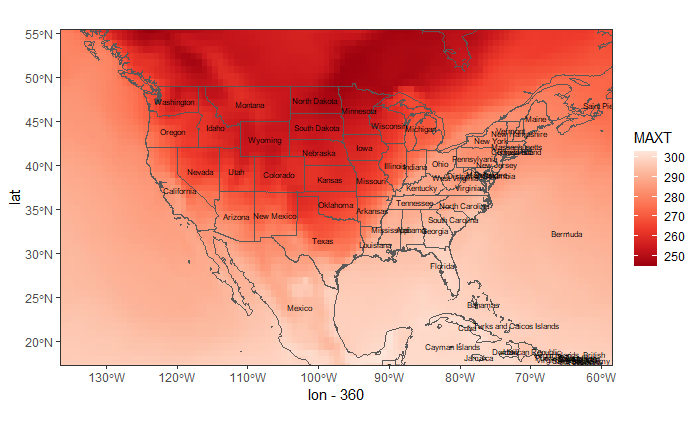

```r
us.states$ID <- toTitleCase(as.vector(us.states$ID))

#### County boundaries. The st_area function calculates are within the polygon.
#### This function might be useful later down the road.
counties <- st_as_sf(map("county", plot = FALSE, fill = TRUE))
counties$area <- as.numeric(st_area(counties))

#### Plot maximum temperature slice over US map with counties
ggplot() +
  # Plot area of interest from ERA-Interim dataset
  geom_raster(data = dataset, aes(x = lon - 360, y = lat, fill = MAXT)) +
  # Reds color pallete for heat map
  scale_fill_distiller(palette = "Reds") +
  # Draws world map
  geom_sf(data = map, fill = NA) +
  # Draws US states map
  geom_sf(data = us.states, fill = NA) +
  # Add US state names
  geom_text(data = us.states, aes(X, Y, label = ID), size = 2) +
  # Add country names
  geom_text(data = map, aes(X, Y, label = ID), size = 2) +
  theme_bw() +

  #NB: needed to change the way the bounds are set for plotting:

  coord_sf(xlim = c(min(maxt.df$lon) - 360,
                    max(maxt.df$lon) - 360),
           ylim = c(min(maxt.df$lat),
                    max(maxt.df$lat)),
           expand = FALSE)
```

Let’s explore some time series at different locations, such as Ft. Collins, which is located at 40.58N, 105.08W. The closest coordinate in the data is: (255, 40.5) as a lon/lat point.

```r
maxt.ts <- getCDF.data(filePath = file.maxt, lonRange = c(255,255), latRange = c(40.5,40.5), timeRange = c(0,14245))
mint.ts <- getCDF.data(filePath = file.mint, lonRange = c(255,255), latRange = c(40.5,40.5), timeRange = c(0,14245))
prec.ts <- getCDF.data(filePath = file.prec, lonRange = c(255,255), latRange = c(40.5,40.5), timeRange = c(0,14245))
```

Now let’s join into a single data-frame and get a usable date using Phong’s `ParseNetCDFTime()` function:

```r
data.ts <- full_join(maxt.ts, mint.ts) %>% full_join(prec.ts) %>% select(MINT, MAXT, PREC, lon, lat, time)
data.ts <- data.ts %>% mutate(date = ParseNetCDFTime(file.maxt, data.ts))
head(data.ts)
```

| MINT | MAXT | PREC | lon | lat | time | date |
| --- | --- | --- | --- | --- | --- | --- |
| 248.2261 | 258.2731 | 0.001522288 | 255 | 40.5 | 0 | 1979-01-01 |
| 252.7928 | 268.8328 | 0.000000000 | 255 | 40.5 | 1 | 1979-01-02 |
| 256.8616 | 272.7576 | 0.000000000 | 255 | 40.5 | 2 | 1979-01-03 |
| 264.8359 | 273.0940 | 0.002899334 | 255 | 40.5 | 3 | 1979-01-04 |
| 260.2937 | 268.8923 | 0.002073094 | 255 | 40.5 | 4 | 1979-01-05 |
| 263.1974 | 268.6235 | 0.001011506 | 255 | 40.5 | 5 | 1979-01-06 |

Now we can plot the maximum temp, minimum temp, in the area over FT. Collins:

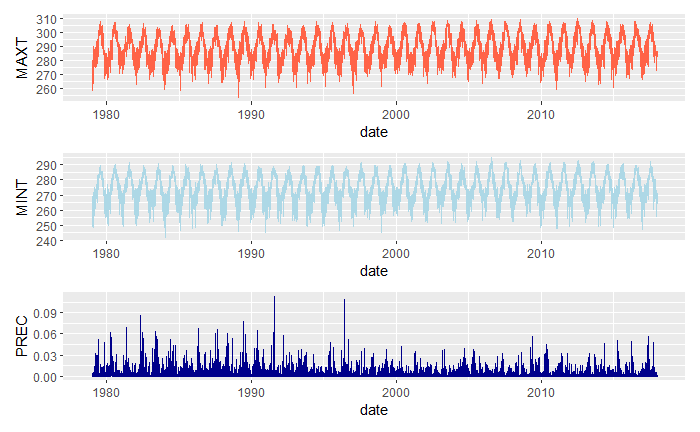

```r
tempMAX.plot <- ggplot(data.ts, aes(x = date, y = MAXT)) +
              geom_line(color = "tomato")

tempMIN.plot <- ggplot(data.ts, aes(x = date, y = MINT)) +
              geom_line(color = "lightblue")

prec.plot <- ggplot(data.ts, aes(x = date, y = PREC)) +
              geom_line(color = "darkblue")

tempMAX.plot/tempMIN.plot/prec.plot
```